# Group_1

David,Andi,Justin

2022-05-22

Motivation: Red wine has received more and more attention in the field of health preservation. Therefore, how to taste fine wine and choose red wine has become a problem that more and more people are concerned about. What physical and chemical properties of red wine can meet people’s needs for health preservation?

Data: Our data set is from Kaggle. The entire data set has 12 attributes. One of the variables “quality” represents the rating of the wine by wine experts (0-10). The table below shows details

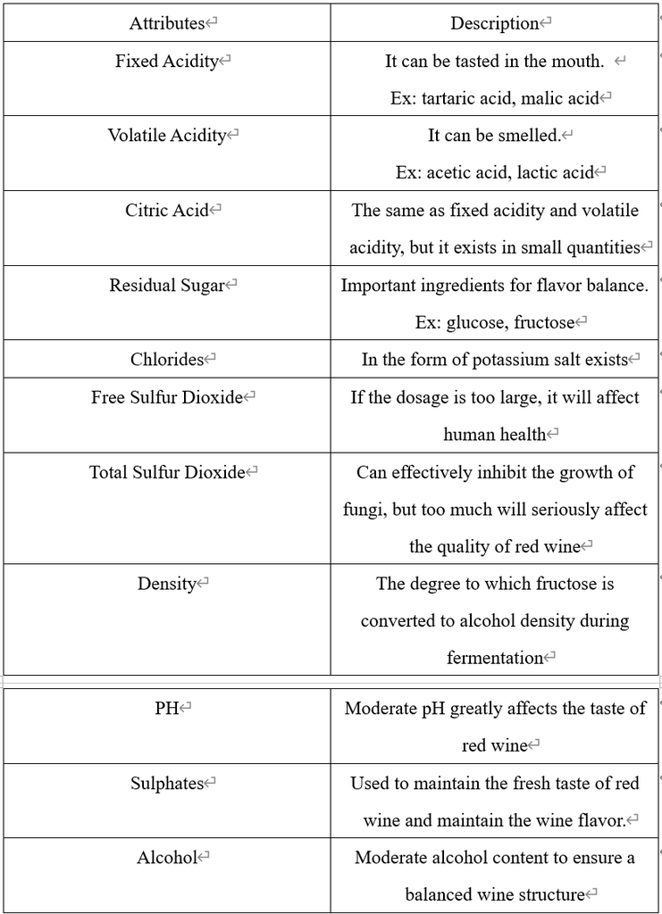

From the background information, residual sugar, all acidity, and alcohol combine to create a wine’s balance of flavor: acidity provides depth to the wine’s flavor, while neutralizing the residual sugar to keep the wine fresh; alcohol adds to the palate more burning sensation. So, we can know that the quality of red wine mostly depends on “Fixed Acidity”, “Volatile Acidity”, “Citric Acid”, “Residual Sugar”, “PH”, “Density” and “Alcohol”.

Objective: After knowing some background knowledge of red wine and simple data processing, we asked the following questions for this project: 1. What is the difference between a high-rated red wine and a low-rated red wine? 2. To what extent do the physical and chemical properties of red wine determine the quality of red wine?

## Brief Introduction of Data

```
## 'data.frame':    1599 obs. of  8 variables:
##  $ fixed.acidity   : num  7.4 7.8 7.8 11.2 7.4 7.4 7.9 7.3 7.8 7.5 ...
##  $ volatile.acidity: num  0.7 0.88 0.76 0.28 0.7 0.66 0.6 0.65 0.58 0.5 ...
##  $ citric.acid     : num  0 0 0.04 0.56 0 0 0.06 0 0.02 0.36 ...
##  $ residual.sugar  : num  1.9 2.6 2.3 1.9 1.9 1.8 1.6 1.2 2 6.1 ...
##  $ density         : num  0.998 0.997 0.997 0.998 0.998 ...
##  $ pH              : num  3.51 3.2 3.26 3.16 3.51 3.51 3.3 3.39 3.36 3.35 ...
##  $ alcohol         : num  9.4 9.8 9.8 9.8 9.4 9.4 9.4 10 9.5 10.5 ...
##  $ quality         : int  5 5 5 6 5 5 5 7 7 5 ...
```

```
##                  vars    n  mean   sd median trimmed  mad  min   max range skew
## fixed.acidity       1 1599  8.32 1.74   7.90    8.15 1.48 4.60 15.90 11.30 0.98
## volatile.acidity    2 1599  0.53 0.18   0.52    0.52 0.18 0.12  1.58  1.46 0.67
## citric.acid         3 1599  0.27 0.19   0.26    0.26 0.25 0.00  1.00  1.00 0.32
## residual.sugar      4 1599  2.54 1.41   2.20    2.26 0.44 0.90 15.50 14.60 4.53
## density             5 1599  1.00 0.00   1.00    1.00 0.00 0.99  1.00  0.01 0.07
## pH                  6 1599  3.31 0.15   3.31    3.31 0.15 2.74  4.01  1.27 0.19
## alcohol             7 1599 10.42 1.07  10.20   10.31 1.04 8.40 14.90  6.50 0.86
## quality             8 1599  5.64 0.81   6.00    5.59 1.48 3.00  8.00  5.00 0.22
##                  kurtosis   se
## fixed.acidity        1.12 0.04
## volatile.acidity     1.21 0.00
## citric.acid         -0.79 0.00
## residual.sugar      28.49 0.04
## density              0.92 0.00
## pH                   0.80 0.00
## alcohol              0.19 0.03
## quality              0.29 0.02
```

## Visualization

[interactive chart not shown]

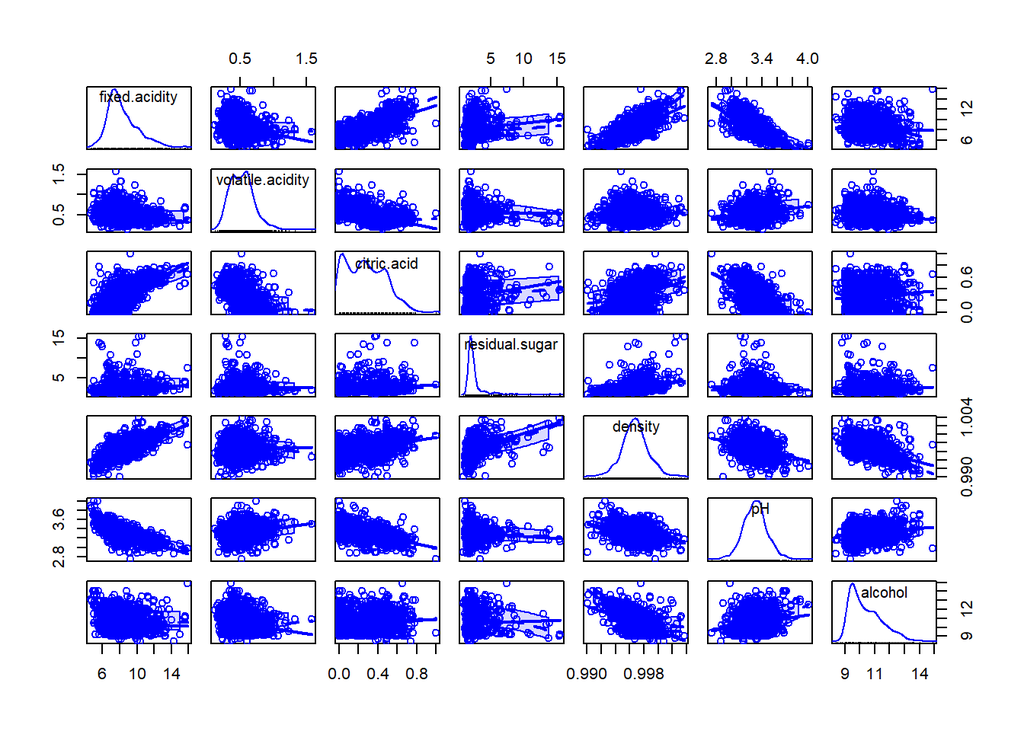

## Define Estimate Function

```r
# Jack Knife
jackknife<-function(col){
    n<-length(col)
    jackmean<-numeric(n)
    jackvar<-numeric(n)
    for (i in 1:n){
        jackmean[i]<-mean(col[-i])
        jackvar[i]<-var(col[-i])
    }
    return(c(mean(jackmean),mean(jackvar)))
}

# Bootstrap mean and var
bootstrap<-function(seed_num,col,B){
    set.seed(seed_num)
    n<-length(col)
    bootmean<-numeric(n)
    bootvar<-numeric(n)
    for (b in 1:B){
        i<-sample(1:n,size = n,replace = TRUE)
        bootmean[i]<-mean(col[i])
        bootvar[i]<-var(col[i])
    }
    return(c(mean(bootmean[i]),mean(bootvar[i])))
}

# Bootstrap bias and error
bootstrapE<-function(seed_num,col,B){
    set.seed(seed_num)
    n<-length(col)
    bootmean<-numeric(n)
    bootvar<-numeric(n)
    for (b in 1:B){
        i<-sample(1:n,size = n,replace = TRUE)
        bootmean[i]<-mean(col[i])
        bootvar[i]<-var(col[i])
    }
    bias_mean<-mean(bootmean[i])-mean(col)
    bias_var<-mean(bootvar[i])-var(col)
    se_mean<-sd(bootmean)
    se_var<-sd(bootvar)
    return(c(bias_mean,se_mean,bias_var,se_var))
}

## with no optimization
MLEOP<- function(theta,x) {
    mu<-theta[1]
    var<-theta[2]
    return (-(-(n/2)*log(2*pi)-(n/2)*log(var)-(1/(2*var))*sum((x-mu)^2)))
}

# EM algorithm for mixture estimations
gmm <- function(x, mean, sd = NULL)
{
    # initialize
    num <- length(mean)

    epsilon <- 1e-4
    probs <- rep(1/num, num)
    mu_s <- mean
    sigma_s <- sd ^ 2
    n <- length(x)
    while(TRUE)
    {
        # E-step calculate estimated prob
        ps <- matrix(0, ncol = num, nrow = n)
        for(j in seq(num))
        {
            ps[, j] <- probs[j] * dnorm(x, mean = mu_s[j], sd = sqrt(sigma_s[j]))
        }
        ps <- ps / rowSums(ps)

        sigma_s_p <- sigma_s
        # M-step update the mean, sigma and prob
        for(j in seq(num))
        {
            sigma_s[j] <- sum( ps[, j] * (x - mu_s[j])^2) / sum(ps[, j])
            mu_s[j] <- sum(x * ps[, j]) / sum(ps[, j])
            probs[j] <- mean(ps[, j])

        }

        if (max(abs(sigma_s_p - sigma_s)) < epsilon)
        {
            break
        }

    }

    return (list(mu = mu_s, var = sigma_s, prob = probs))

}
```

## Show the Histogram and Kernel Density Estimates

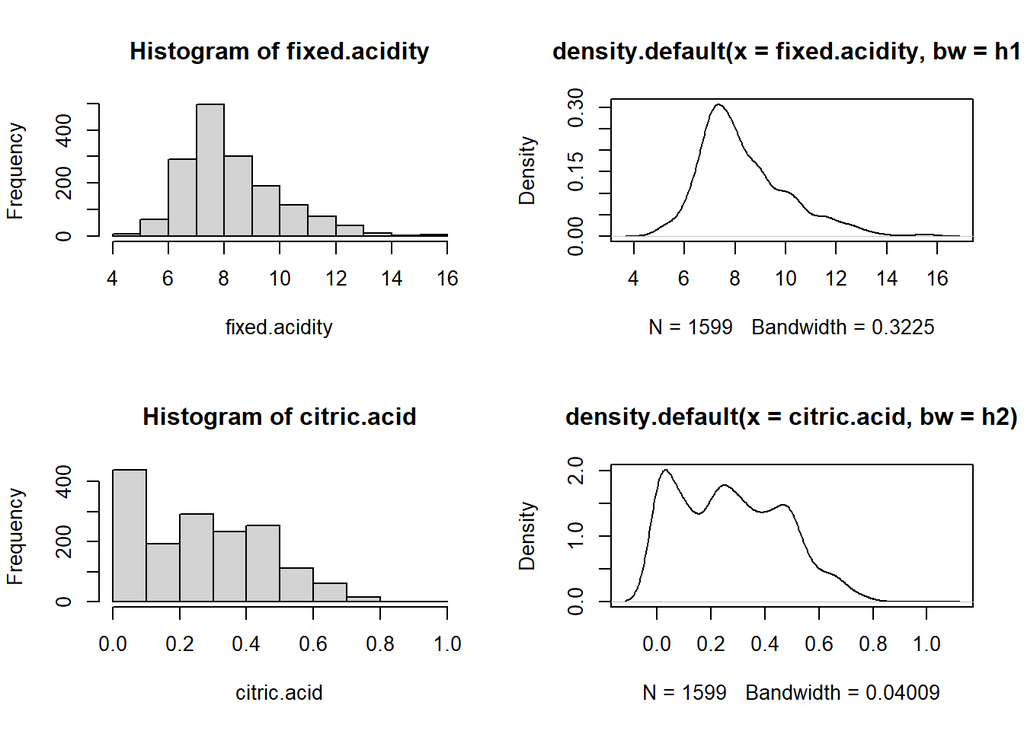

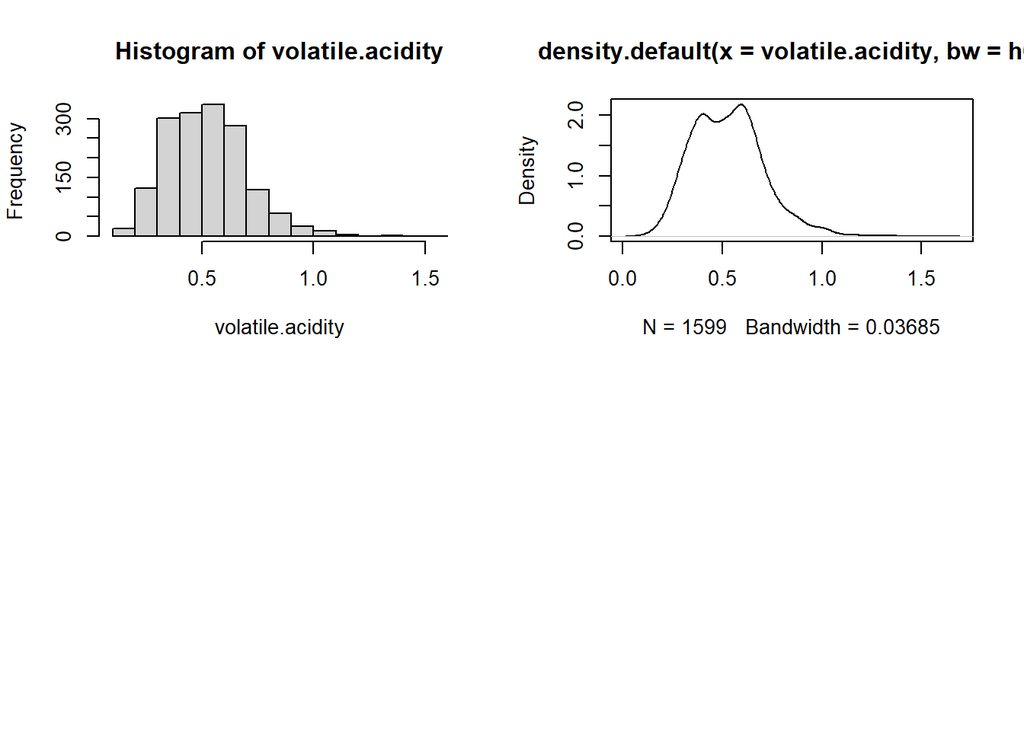

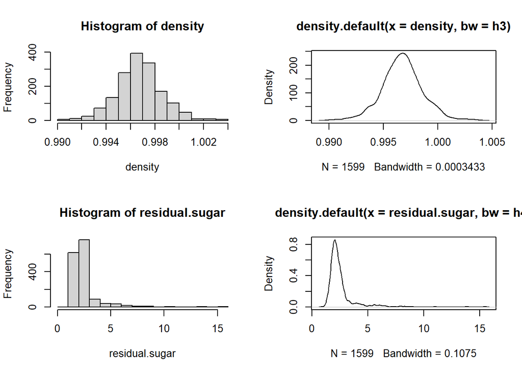

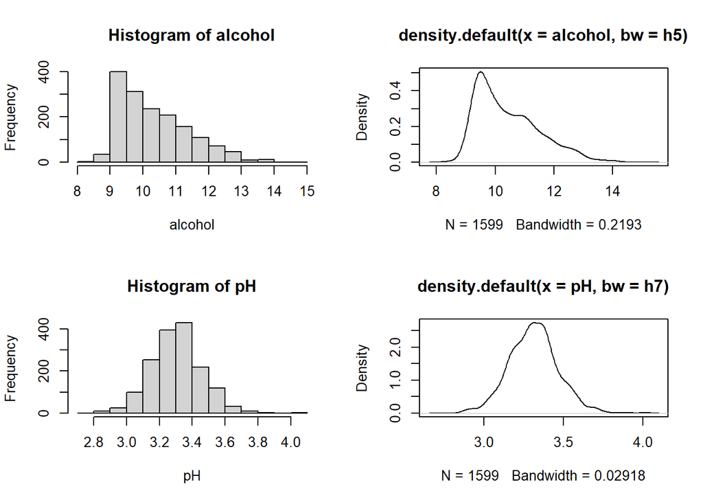

For the Kernel density estimates, all variable we use the Gaussian Kernel, K(t)=1/√2π exp(-1/2 t^2). In addition, for unimodal distribution we set a better estimate for Gaussian $h=0.9 min(S,\frac{IQR}{1.34})n^{-\frac{1}{5}}$. But for which is not unimodal, we set $\hat \sigma=min(S,\frac{IQR}{1.34}))$.

## Explain Keneral Density Estimates

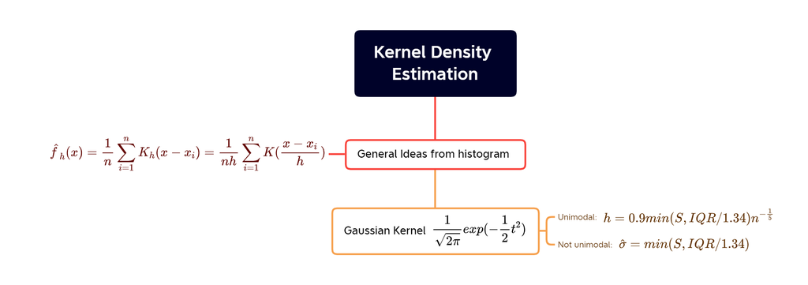

Kernel density estimation is used in probability theory to estimate the unknown density function, which belongs to one of the non-parametric test methods. Since the kernel density estimation method does not use prior knowledge about the data distribution, it does not attach any assumptions to the data distribution. The method of studying the characteristics of data distribution from the data sample itself. The ideas of Kernel Density Estimation are generated from histogram. If we draw a histogram, the purpose is to draw a “probability density function”, and a histogram essentially thinks that frequency equals probability. But this assumption is not inevitable. The kernel density function is a means of “smoothing”. For example, let (x1,x2,…,xn) be n sample points that are independent and identically distributed, and its probability density function is f, so our estimate: $\hat f_h(x)=\frac{1}{nh}=\sum_{i=1}^nK(\frac{x-x_i}{h})$. Here h is the bandwidth. For Gaussian Kernel, if the distribution is unimodal, we need to set $h=0.9 min(S,\frac{IQR}{1.34})n^{-\frac{1}{5}}$. In addition, if the distribution is not unimodal, we need set $\hat \sigma=min(S,\frac{IQR}{1.34})$.

## Explain MLE

The formula for Gaussian Distribution
$$f(x)=\frac{1}{\sqrt{2\pi
\sigma^2}}e^{-\frac{(x-\mu)^2}{2\sigma^2}}$$
$$L(f(x))=(\frac{1}{\sqrt{2\pi \sigma^2}})^n
e^{\sum_{i=1}^n -\frac{(x_i-\mu)^2}{2\sigma^2}}$$
$$ln(L(f(x)))=-\frac{n}{2}(ln{(2\pi)}+ln(\sigma^2))
- {\sum_{i=1}^n \frac{(x_i -\mu)^2}{2\sigma^2}}$$
$$\frac{\partial ln(L)}{\partial
\mu}=\frac{1}{\sigma^2}\sum_{i=1}^n (x_i -\mu)=0$$
$$\frac{\partial ln(L)}{\partial
\sigma^2}=-\frac{n}{2\sigma^2}+\frac{1}{2\sigma^4}\sum_{i=1}^n (x_i
-\mu)^2=0$$

```
## [1] "Fixed Acidity"
```

```
## [1] "Bootstrap Mean: 8.26960600375235"
```

```
## [1] "Bootstrap var: 3.02195422514541"
```

```
## [1] "Jacknife Mean: 8.31963727329581"
```

```
## [1] "Jacknife Var: 3.03141638899782"
```

```
## [1] "Sample Mean: 8.31963727329581"
```

```
## [1] "Sample Var: 3.03141638899782"
```

```
## [1] "MLE Mean: 8.32017966701533"
```

```
## [1] "MLE Var: 3.03254901797268"
```

```
## [1] "Cirtic Acdity"
```

```
## [1] "Bootstrap Mean: 0.273652282676673"
```

```
## [1] "Bootstrap var: 0.0392374660007311"
```

```
## [1] "Jacknife Mean: 0.270975609756098"
```

```
## [1] "Jacknife Var: 0.0379474831344058"
```

```
## [1] "Sample Mean: 0.270975609756098"
```

```
## [1] "Sample Var: 0.0379474831344058"
```

```
## [1] "MLE Mean: 0.270966369940073"
```

```
## [1] "MLE Var: 0.0379291736811019"
```

```
## [1] "Cirtic Acdity"
```

```
## [1] "Bootstrap Mean: 0.273652282676673"
```

```
## [1] "Bootstrap var: 0.0392374660007311"
```

```
## [1] "Jacknife Mean: 0.270975609756098"
```

```
## [1] "Jacknife Var: 0.0379474831344058"
```

```
## [1] "Sample Mean: 0.270975609756098"
```

```
## [1] "Sample Var: 0.0379474831344058"
```

```
## [1] "EM outputs"
```

```
## $mu
## [1] 0.02664168 0.19459247 0.42916942
##
## $var
## [1] 0.0008544612 0.0073184049 0.0187964911
##
## $prob
## [1] 0.2131746 0.3085773 0.4782481
```

```
## [1] "EM Mean 0.270975609756098"
```

```
## [1] "EM Var 0.0379248076881828"
```

```
## [1] "Density"
```

```
## [1] "Bootstrap Mean: 0.996700781738587"
```

```
## [1] "Bootstrap var: 3.49810007686281e-06"
```

```
## [1] "Jacknife Mean: 0.996746679174484"
```

```
## [1] "Jacknife Var: 3.56202945332698e-06"
```

```
## [1] "Sample Mean: 0.996746679174484"
```

```
## [1] "Sample Var: 3.56202945332698e-06"
```

```
## [1] "MLE Mean: 0.996746673199279"
```

```
## [1] "MLE Var: 3.5606124418882e-06"
```

```
## [1] "Residual Sugar"
```

```
## [1] "Bootstrap Mean: 2.53589743589744"
```

```
## [1] "Bootstrap var: 2.129345736658"
```

```
## [1] "Jacknife Mean: 2.53880550343965"
```

```
## [1] "Jacknife Var: 1.98789713298596"
```

```
## [1] "Sample Mean: 2.53880550343965"
```

```
## [1] "Sample Var: 1.98789713298596"
```

```
## [1] "MLE Mean: 2.53896975615089"
```

```
## [1] "MLE Var: 1.98693607002443"
```

```
## [1] "Alcohol"
```

```
## [1] "Bootstrap Mean: 10.415749426725"
```

```
## [1] "Bootstrap var: 1.08912271536871"
```

```
## [1] "Jacknife Mean: 10.4229831144465"
```

```
## [1] "Jacknife Var: 1.13564739500047"
```

```
## [1] "Sample Mean: 10.4229831144465"
```

```
## [1] "Sample Var: 1.13564739500047"
```

```
## [1] "MLE Mean: 10.4230233509144"
```

```
## [1] "MLE Var: 1.13408579497747"
```

```
## [1] "Volatile Acidity"
```

```
## [1] "Bootstrap Mean: 0.522983114446529"
```

```
## [1] "Bootstrap var: 0.032133335759756"
```

```
## [1] "Jacknife Mean: 0.527820512820513"
```

```
## [1] "Jacknife Var: 0.0320623776515516"
```

```
## [1] "Sample Mean: 0.527820512820513"
```

```
## [1] "Sample Var: 0.0320623776515516"
```

```
## [1] "MLE Mean: 0.52781629613742"
```

```
## [1] "MLE Var: 0.0320405111771588"
```

```
## [1] "pH"
```

```
## [1] "Bootstrap Mean: 3.31772357723577"
```

```
## [1] "Bootstrap var: 0.0236424992622892"
```

```
## [1] "Jacknife Mean: 3.31111319574734"
```

```
## [1] "Jacknife Var: 0.0238351805454128"
```

```
## [1] "Sample Mean: 3.31111319574734"
```

```
## [1] "Sample Var: 0.0238351805454128"
```

```
## [1] "MLE Mean: 3.31107909416666"
```

```
## [1] "MLE Var: 0.0238015994138302"
```

## Basic analysis for a glance

After we select the variables we interested. We draw the scatter matrix for better viewing the correlation coefficient values and scatter plots between two variables to explore more information between these data.

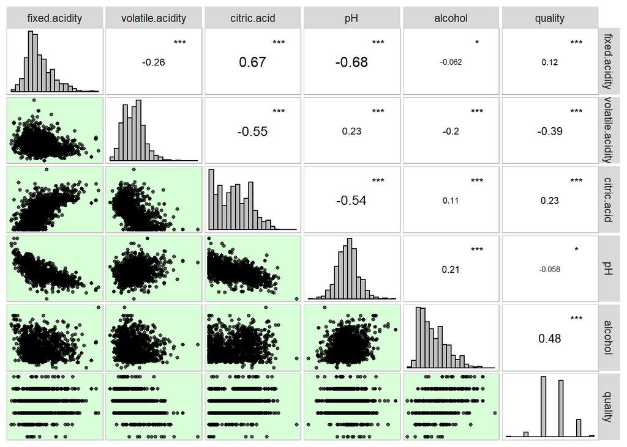

Besides, we use the powerTransform function to detect whether the variable is suitable for logarithms.

```
## Estimated transformation parameter
## fixed.acidity
##    -0.6686188
```

```
## Estimated transformation parameter
## volatile.acidity
##        0.3996503
```

```
## Estimated transformation parameter
## citric.acid
##    0.444153
```

```
## Estimated transformation parameter
##          pH
## -0.02910134
```

```
## Estimated transformation parameter
##   alcohol
## -3.326066
```

The variable which is close to zero, the log-transformtion is suggested. And the variable which is about 0.5, then the corresponding variable would be replaced by its square root. These result can be very useful when we select the variable for the model by hand.

## Select the model by jackknife

Then we will select the model and using the jackknife to find the suitable model. The workflow is to mask one of the data one by one in order. We just select one of the variables each search. For each mask, we use the remaining data for building model. And then use the data being masked to make prediction, and get the error of it.The best variable with the best model has the lowest error square mean.

We totally using two ways to find the variable with corresponding coefficient.

### Grid search

We firstly apply most simple but time consuming method to obtain the best model, which is searching one by one with the following form.

1. Linear: $Y = \beta_0 + \beta_1 X +\varepsilon$
2. Quadratic: $Y = \beta_0 + \beta_1 X + \beta_1 X^2 +\varepsilon$
3. Square root: $Y = \beta_0 + \beta_1 \sqrt{X}+\varepsilon$

And the variable which have the smallest error when using the jackknife method to build the corresponding model and make the prediction for the data. After we get the best one, we continuing adding new variable to conduct another operation to find the next variables and the model. The one of step ranking is shown in here, 1 means the linear form, 2 means the quadratic form and 3 means the square root form.

```
##             X_name   E2_mean E_type_list
## 5          alcohol 0.5049280           3
## 2 volatile.acidity 0.5520683           3
## 3      citric.acid 0.6200631           1
## 1    fixed.acidity 0.6434412           1
## 4               pH 0.6513262           1
```

Thus, we can finally get the function which is looks like as follows:

$$Y = \sqrt{alcohol} + volatile.acidity + fixed.acidity + fixed.acidity^2
+ citric.acid + pH$$

### Select by hand

After we went through the previously obtained information, including the results of powerTransform, correlation coefficient plot, and scatter plot between two two variables, we manually selected the model by experience and finally obtained the following model.

$$Y = \sqrt{alcohol} + volatile.acidity + \sqrt{fixed.acidity} +
\sqrt{citric.acid} + log(pH)$$

### Final comparison and the view of performance

We make the final comparison for the model we select by hand and the model we select by grid search

```
## [1] "Model from gird search"
```

```
## [1] 0.4421088
```

```
## [1] "Model select by hand"
```

```
## [1] 0.44253
```

Thus, from the result we can notice that the model gain from the grid search is better than the model we selected by hand. Now we will make analysis for this model.

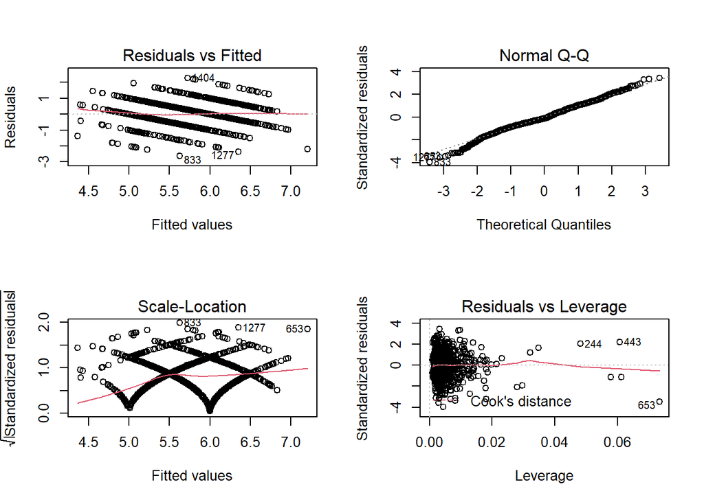

We then draw the four graph to have a better view of the performance of the model. We can see that the QQ plot is mostly normal distribution, and the line is almost fit all the point. And the residuals are acceptable since the quality is a qualitative variables which use the number to represent it

## Get the bias and standard error of the estimator

Then we conduct the bootstrap method to get the bias and standard error of the estimator. We use the sample as the original value of the estimator. And we use the bootstrap to generate a lot of samples to build model by lm function and get new estimator. The result is listing here.

```
## [1] "Bias coefficient mean:"
```

```
##             (Intercept)      sqrt(data$alcohol)   data$volatile.acidity
##            -0.955722538            -0.036399877            -0.006057765
##      data$fixed.acidity I(data$fixed.acidity^2)        data$citric.acid
##             0.036694673            -0.001305644             0.033851395
##                 data$pH
##             0.258478893
```

```
## [1] "Bias coefficient standard deviation:"
```

```
##             (Intercept)      sqrt(data$alcohol)   data$volatile.acidity
##             0.718303147             0.117070232             0.132422456
##      data$fixed.acidity I(data$fixed.acidity^2)        data$citric.acid
##             0.095187219             0.005288444             0.137693450
##                 data$pH
##             0.108792868
```

From the results, we can see that the values of some Bias coefficient mean are satisfied, but some of them are still relatively high, so there is still room for improvement of this model. We can optimize this model by trying more combinations, and this is also the direction we can further improve in the future.

## Simulation

```r
mydata<-read.csv("winequality-red.csv")
```

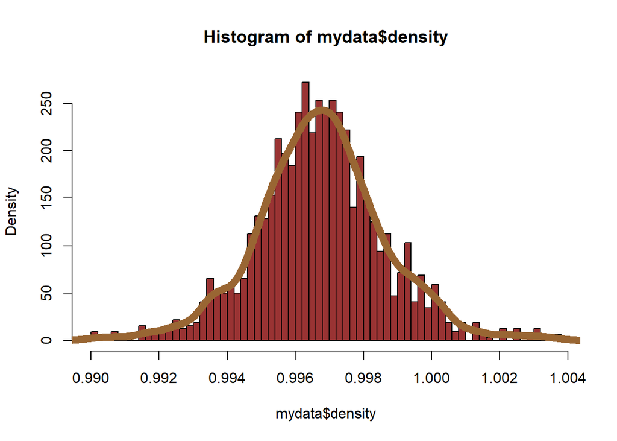

```r
hist(mydata$density,freq=FALSE,breaks=50,col="#993333",prob=TRUE)
lines(density(mydata$density),col="#996633",lwd=8)
```

we can see that,①The peak is in the middle. ②Both sides gradually decreasing ③The two sides are nearly symmetrical④The ends do not intersect with the x-axis，so it follow the normal distribution. for the ML_function, we can get the mean and variance:

Firstly, we used the optimized method to get the mean and variance: For the big sample:

```r
#mean and standard variance
LL <- function(theta,x) {
    mu<-theta[1]
    var<-theta[2]
    return (-(-(n/2)*log(2*pi)-(n/2)*log(var)-(1/(2*var))*sum((x-mu)^2)))
}
optim(c(1,1), LL,x=mydata$density)
```

The value methods is used to calculate the the population mean and variance in different method(MLE/Sample):

```r
values<-function(sample){
m<-mean(sample)
s_l<-sum(((sample)-mean(sample))^2)/(length(sample))#ml
s_s<-sum(((sample)-mean(sample))^2)/(length(sample)-1)
list(mu = m, s_mle = s_l, s_sample = s_s)
}
values(mydata$density)
```

We write a method to help us calculate different evaluations.The method is used to calculate the Monte Carlo the MEAN/STD/MSE:

```r
evaluation<-function(sample,mean,vars){
  #"sample" is the size of the simulation sample
  #"mean" is the the mean of different methods mean value
  #"vars" is the the variance of different methods variance value
df <- matrix(NA,sample,1)
df <- as.data.frame(df)
n=400
for (i in 1:n) {
  df[,i] <- rnorm(sample,mean,sqrt(vars))
}
df2 <- data.frame(mean=NA,ss2=NA)
df3 <- data.frame(mean=NA,ss2=NA)
for (i in 1:n){
  t1 <- mean(df[,i])
  t2 <- sum(((df[,i])-mean(df[,i]))^2)/length(df[,i])#ml method
  df2[i,] <- c(t1,t2)
  t3 <- mean(df[,i])
  t4 <- sum(((df[,i])-mean(df[,i]))^2)/(length(df[,i])-1)#sample method
  df3[i,] <- c(t3,t4)
}
#ml
msef<-data.frame(meanv1=NA,sv1=NA)
n=400#the repeat time
for(u in 1:n){
  mse1<-(df2[u,2]-(mean(df2$ss2)))^2
  mv1<-(df2[u,1]-(mean(df2$mean)))^2
  msef[u,]<-c(mv1,mse1)
}
res_s=mean(msef$sv1)+(mean(df2$ss2)-vars)^2
res_m=mean(msef$meanv1)+(mean(df2$mean)-mean)^2
#sample
msef1<-data.frame(meanv2=NA,sv2=NA)
n=400
for(u in 1:n){
  mse1<-(df3[u,2]-(sum(df3$ss2)/400))^2
  mv1<-(df3[u,1]-(sum(df3$mean)/400))^2
  msef1[u,]<-c(mv1,mse1)
}
c<-sum(msef1$sv2)/400
res_s1=c+(sum(df3$ss2)/400-vars)^2
d<-sum(msef1$meanv2)/400
res_m1=d+(sum(df3$mean)/400-mean)^2
list(mu_mle = mean(df2$mea), std_mle =mean(df2$ss2) ,m_sample= mean(df3$mean),std_sample=mean(df3$ss2),mse_mle_mean = res_m, mse_mle_var =res_s,mse_sample_mean = res_m1, mse_sample_var =res_s1)
}
```

We can use the above function to get the result for the population of “density” of the red wine.

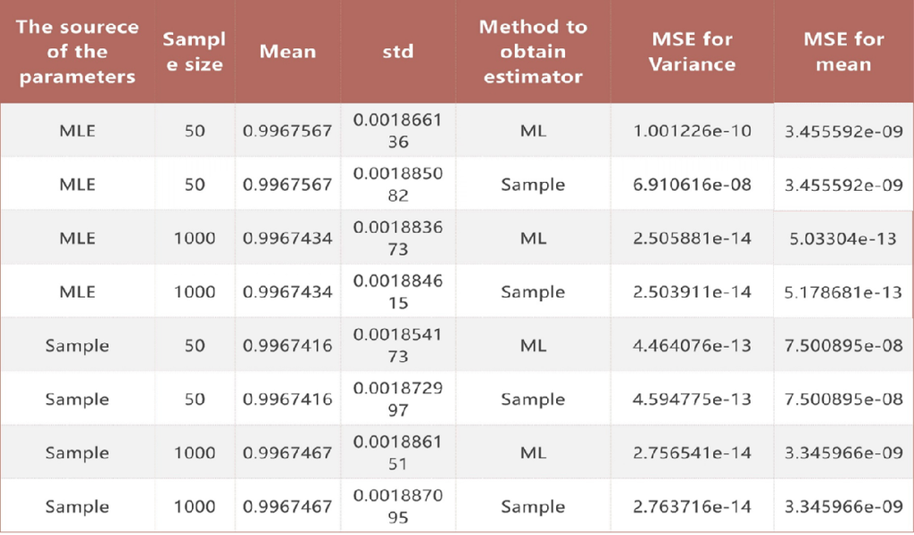

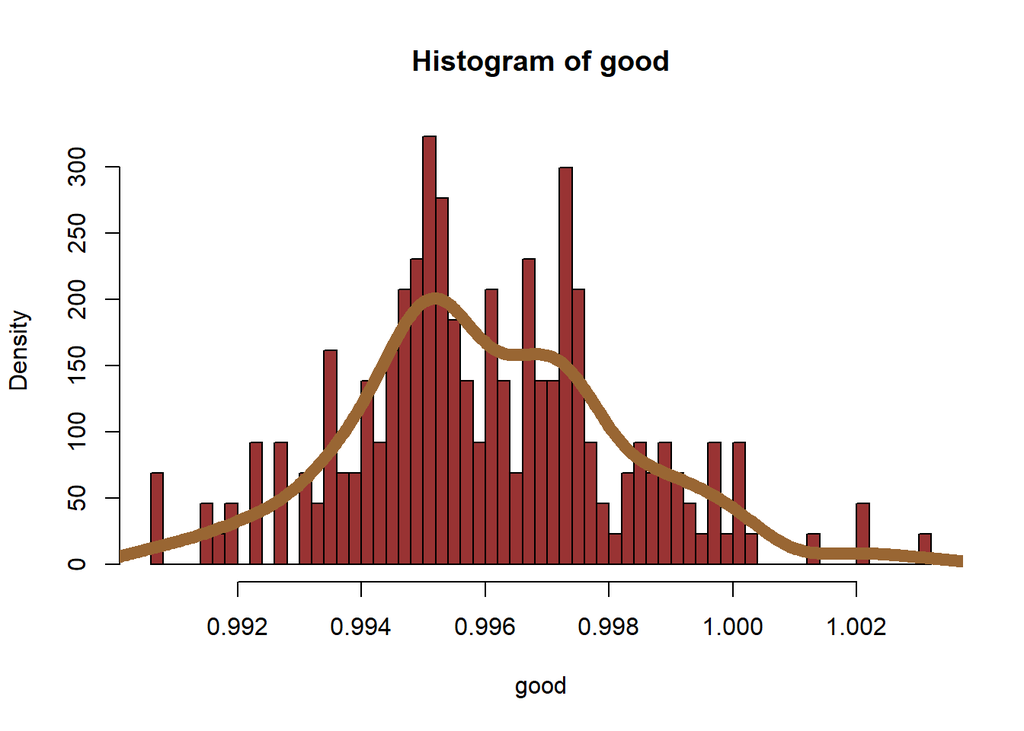

```r
good<-mydata$density[mydata$quality>=7]
bad<-mydata$density[mydata$quality<7]
#the mixture normal distribution
hist(good,freq=FALSE,breaks=50,col="#993333",prob=TRUE)
lines(density(good),col="#996633",lwd=8)
```

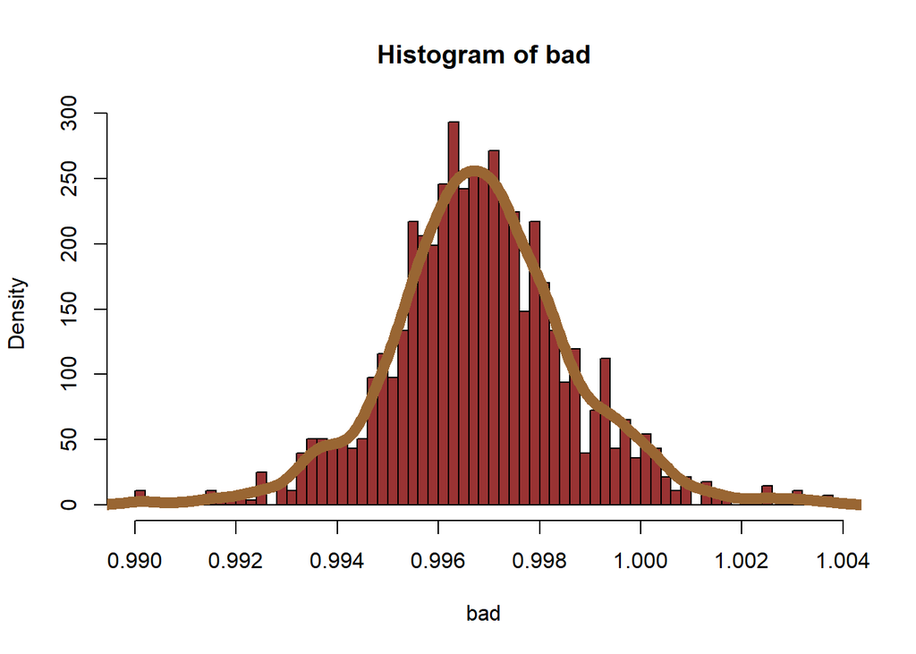

```r
#the normal distribution
hist(bad,freq=FALSE,breaks=50,col="#993333",prob=TRUE)
lines(density(bad),col="#996633",lwd=8)
```

```r
#for the good wine:
evaluation(50,0.9967467,3.559802e-06)
evaluation(1000,0.9967467,3.559802e-06)
evaluation(50,0.9967467,3.562029e-06)
evaluation(1000,0.9967467,3.562029e-06)
#for the bad wine:
evaluation(50,0.9968592,3.268215e-06)
evaluation(1000,0.9968592,3.268215e-06)
evaluation(50,0.9968592,3.270581e-06)
evaluation(1000,0.9968592,3.270581e-06)
```

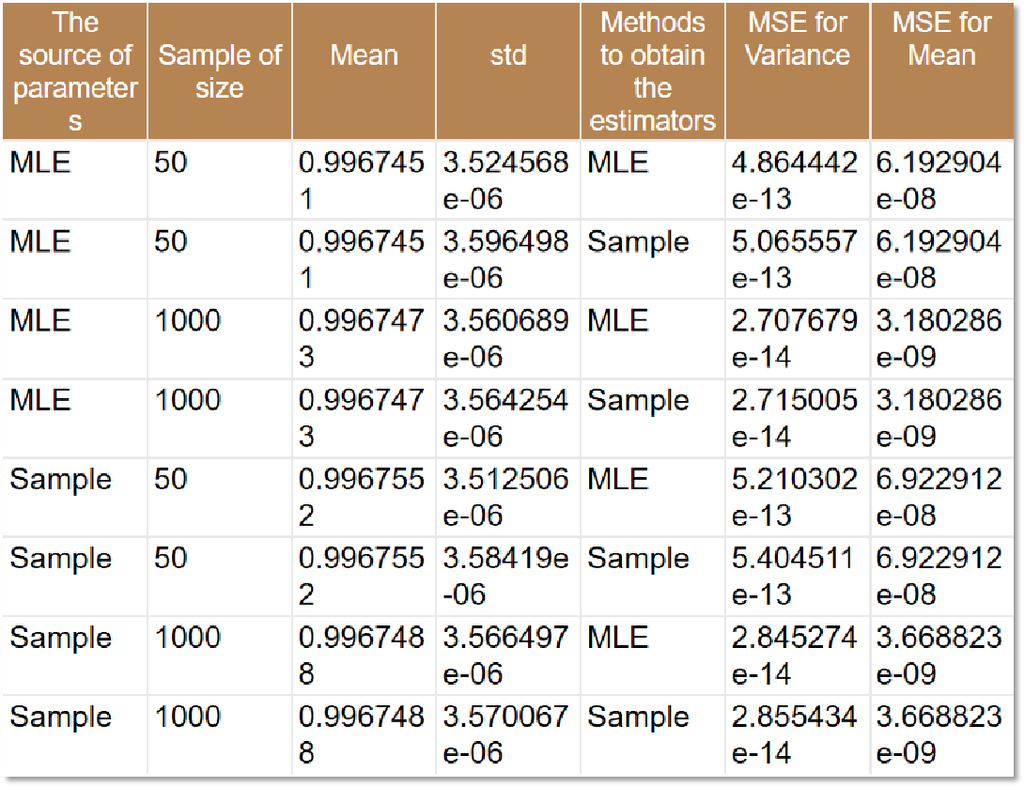

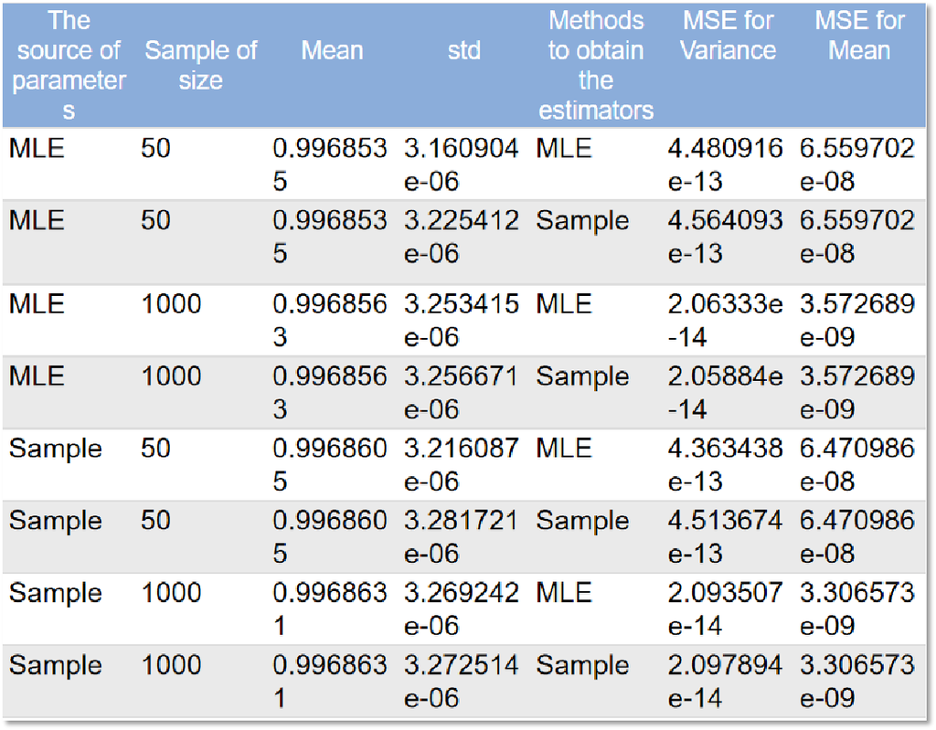